# A Bayesian Analysis of My D&D Dice

This is how the beta-binomial model works when we only care about one face, but what about if we are interested in every face of the dice? To answer that, let’s look at the dirichlet distribution and the dirichlet-multinomial model. We will consider a made up dice that only has three faces, because it will be very difficult to visualize anything higher.

The multinomial distribution is just a higher dimension version of the binomial distribution. In a binomial distribution the probabilty of a failure can be inferred from the probability of a success since there is a constraint that both outcomes must sum to a total probability of 1. In the multinomial we no longer have success and failure, but outcomes 1,2,…,k each with their own probabilities, $p_i$:

$$f(x_1,...,x_k, p1,...,pk) = \frac{n!}{x_1! x_2! ... x_k!}p_1^{x_1}p_2^{x_2} ... p_k^{x_k}$$
Subject to the constaints:

$$\sum_{i=1}^{n} x_i = n$$
and

$$\sum_{j=1}^{k} p_j = 1$$

Hopefully the similarity of the multinomial model to the binomial model is evident. A dirichlet distribution is a higher dimensional generalization of the beta distribution we saw earlier, and so the updating rules for it should also look familiar:

$$Prior = Dir(\theta_1,\theta_2, ..., \theta_k)$$
$$Posterior = Dir(\theta_1 + x_1,\theta_2 + x_2, ..., \theta_k + x_k)$$

But what does a Dirichlet distribution look like? To figure this out we will need to resort to some fancy three dimensional plots. For a three dimensional dirichlet distribution, our probability densities exist on the triangualr surface formed by the equation:

$$p_1 + p_2 + p_3 = 1$$

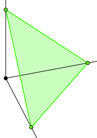

A probability density function defined by the dirichlet distribution exists on this surface:

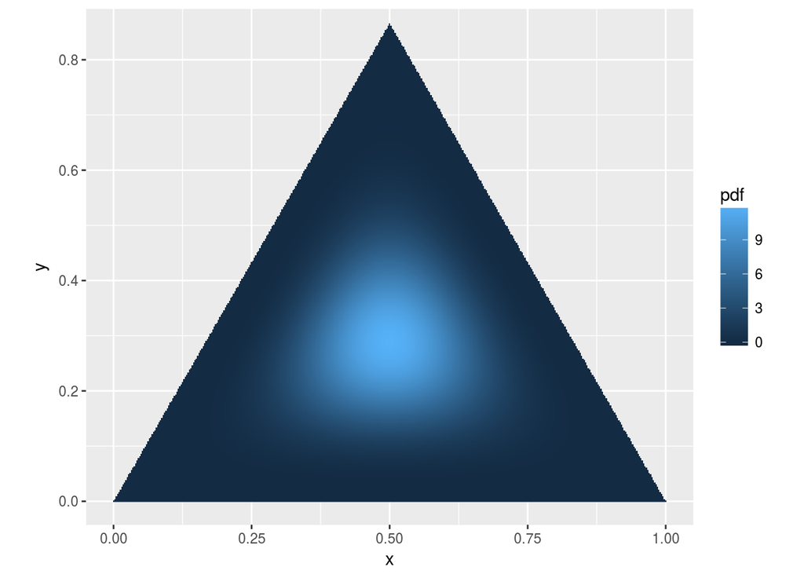

```r
pdf <- function(v) ddirichlet(v, c(5, 5, 5))
mesh <- simplex_mesh(.0025) %>% as.data.frame %>% tbl_df
mesh$pdf <- mesh %>% apply(1, function(v) pdf(bary2simp(v)))

ggplot(mesh, aes(x, y)) +
  geom_raster(aes(fill = pdf)) +
  coord_equal(xlim = c(0,1), ylim = c(0, .85))
```

And as we update our dirichlet distribution using the rules above, it can shift the probability just like we saw for the beta distribution:

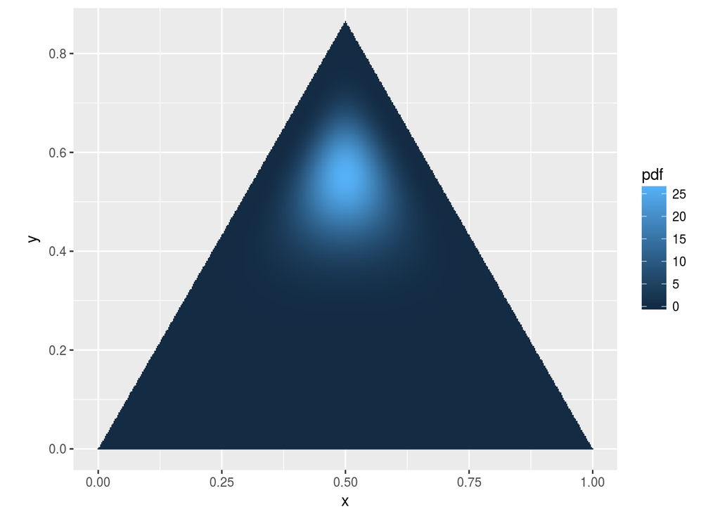

```r
pdf <- function(v) ddirichlet(v, c(5, 5, 15))
mesh <- simplex_mesh(.0025) %>% as.data.frame %>% tbl_df
mesh$pdf <- mesh %>% apply(1, function(v) pdf(bary2simp(v)))

ggplot(mesh, aes(x, y)) +
  geom_raster(aes(fill = pdf)) +
  coord_equal(xlim = c(0,1), ylim = c(0, .85))
```

Unfortunately these visualizations don’t work so well for dice with more than three faces since it is hard to visualSize four or more dimensions.

The dirichlet distribution has a very similar form for the mean as the beta distribution for each of it’s dimensions p_i:

$$E[p_i] = \frac{\theta_i}{\sum_{i=1}^{k} \theta_i}$$
In fact, if we were to just define $\beta$ as the sum of all the $\theta$s except $\theta_i$, and rename $\theta_i$ to $\alpha$, then the mean posterior probability for $\theta_i$ becomes indistinguishable from a beta distribution defined for $\theta_i$ and $\neg \theta_i$.

If we want the know a 95% credible interval for each face, then we can use this same trick to reduce each face of the dice to it’s own beta distribution and find the confidence interval for that. The only caveat to this is that we need to remember that the distributions for each **p** originally came from a dirichlet distribution, and so the condition that the sum of all p equal one still remains. This just means that if the true value for one of the **p** was actually lower than our posterior mean probability, then it would be necessary that one or more of the other faces has a**p** higher than it’s posterior mean in an amount that cumulatively offsets the difference in the first **p**.

I think that’s more than enough background. Let’s start analyzing!

# Analysis

Rather than duplicating a bunch of code for each dice, I will just start by writing a function that can be reused. The parameters passed to the function are:

1. **roll_data:** An integer vector containing the sequence of roll results.
2. **faces:** The number of faces on the dice being analyzed
3. **beta_prior_a:** The value of the alpha parameter to be used in the beta prior distribution
4. **beta_prior_b:** The value of the beta parameter to be used in the beta prior distribution

```r
bayesian_dice_analysis <- function(roll_data, faces = 20, beta_prior_a = 1, beta_prior_b = 1) {

  # Check that no rolls fall outside 1:faces
  if ((sum(roll_data > faces) + sum(roll_data < 0)) > 0) {
    stop(sprintf("Values outside the range 0 to %i were found in the data. Please ensure the faces parameter is correct and check that the data is valid.", faces))
  }

  # Check that alpha and beta are non-negative
  if (beta_prior_a < 0 || beta_prior_b < 0) {
    stop("The alpha and beta priors must both be non-negtive. Please ensure the values specified are correct.")
  }

  results_table <- tibble(face = c(1:faces))

  # Figure our the number of successes per face
  # Not sure how to do this inside a mutate function below
  successes <- c()
  for (i in 1:faces) {
    successes <- rbind(successes, sum(roll_data == i))
  }

  # Add columns for the count of binomial successes and failures
  results_table <- results_table %>%
                    mutate(successes = successes,
                           failures = length(roll_data) - successes)

  # Add the values related to the posterior distribution
  results_table <- results_table %>%
                    mutate(beta_post_a = beta_prior_a + successes,
                           beta_post_b = beta_prior_b + failures,
                           posterior_mean = beta_post_a / (beta_post_a + beta_post_b),
                           posterior_median = qbeta(0.5, beta_post_a, beta_post_b),
                           posterior_mode = (beta_post_a - 1) / (beta_post_a + beta_post_b - 2),
                           ci_95_lower = qbeta(0.025, beta_post_a, beta_post_b),
                           ci_95_upper = qbeta(0.975, beta_post_a, beta_post_b))

  return(results_table)
}
```

The d10 dice is the one that I am really concerned about, so let’s start with it:

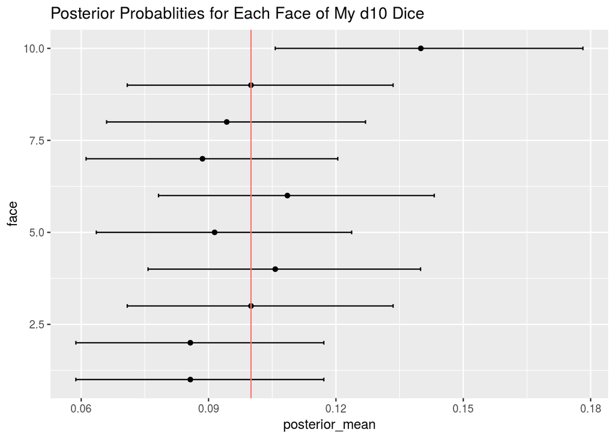

```r
d10_data <- read_csv("d10.csv")
d10_result <- bayesian_dice_analysis(d10_data$Rolls, faces = 10, beta_prior_a = 10, beta_prior_b = 90)

ggplot(d10_result, aes(x = face, y = posterior_mean)) +
  geom_point() +
  geom_errorbar(aes(ymin = ci_95_lower, ymax = ci_95_upper), colour = "black", width = 0.1) +
  geom_hline(aes(yintercept = 0.10, color = "red")) +
  theme(legend.position = "none") +
  coord_flip() +
  ggtitle("Posterior Probablities for Each Face of My d10 Dice")
```

It definitely looks like my d10 is a little unbalanced, and in a favourable way for me.

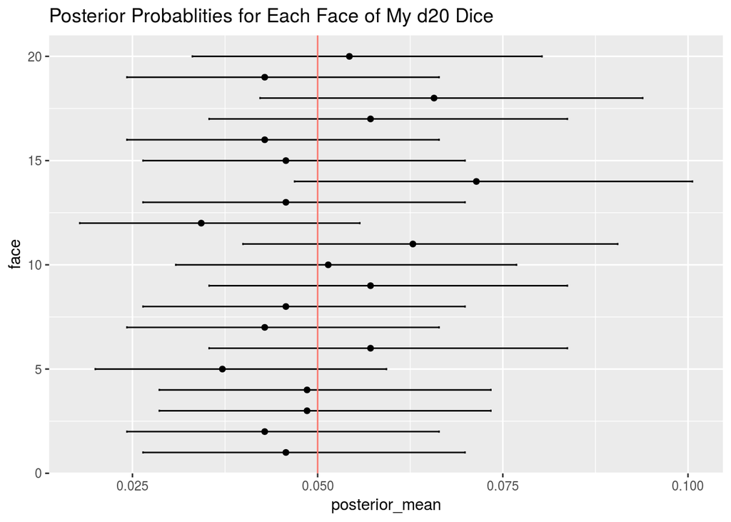

```r
d20_data <- read_csv("d20.csv")
d20_result <- bayesian_dice_analysis(d20_data$Rolls, faces = 20, beta_prior_a = 5, beta_prior_b = 95)

ggplot(d20_result, aes(x = face, y = posterior_mean)) +
  geom_point() +
  geom_errorbar(aes(ymin = ci_95_lower, ymax = ci_95_upper), colour = "black", width = 0.1) +
  geom_hline(aes(yintercept = 0.05, color = "red")) +
  theme(legend.position = "none") +
  coord_flip() +
  ggtitle("Posterior Probablities for Each Face of My d20 Dice")
```

```r
d10_data <- read_csv("d10.csv")
```

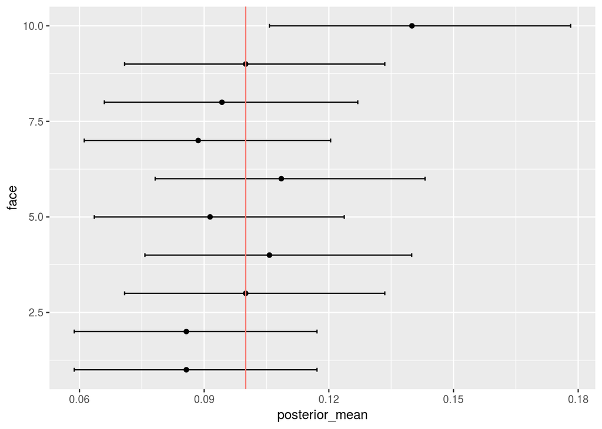

```r
d10_result <- bayesian_dice_analysis(d10_data$Rolls, faces = 10, beta_prior_a = 10, beta_prior_b = 90)

ggplot(d10_result, aes(x = face, y = posterior_mean)) +
  geom_point() +
  geom_errorbar(aes(ymin = ci_95_lower, ymax = ci_95_upper), colour = "black", width = 0.1) +
  geom_hline(aes(yintercept = 0.10, color = "red")) +
  theme(legend.position = "none") +
  coord_flip()
```